# R Notebook

## Dataset preprocessing

```r
library("ggplot2")
library("survival")
library("survminer")
library(rms)
rm(list=ls())

# setwd('/home/mich/Desktop/Poli/Projects/Applied_Statistics/MDS_folder/New_Data')

MDS_data = read.csv("MDS_data.csv")
n = dim(MDS_data)[1]
```

During the preprocessing phase we

- converted all dates in date format
- converted genomic_group to character in order to use it as categorical variable
- converted genomic_group to character in order to use it as numerical variable (**maybe it’s better as categorical?**)
- created dodx: first available diagnosis
- created age: age at dodx
- created time: survival time in days from first diagnosis to last follow up in days (**maybe it’s better in weeks or months?**)
- created other covariates from {dodx, age, WHO}_{prev, ngs, hsct} to make the dataset more simple to use

## Kaplan-Meier and Log-rank test

We start plotting the Kaplan-Meier curve associated to the whole dataset:

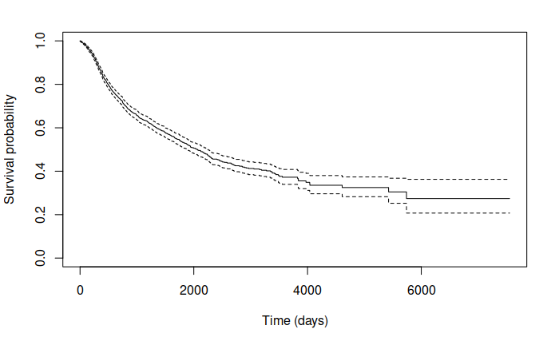

```r
km_model <- survfit(Surv(time, MDS_data$fup_status)~1, data=MDS_data)
plot(km_model,
     xlab = "Time (days)",
     ylab = "Survival probability"
     )                          # add "mark.time = TRUE" to see the censored data
```

Here are the curves for each genomic group

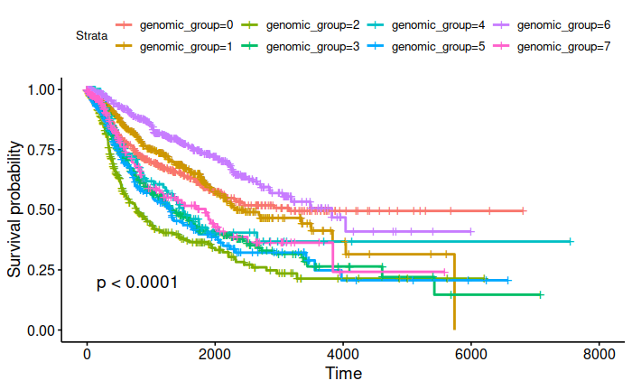

```r
km_genomic = survfit(Surv(time, MDS_data$fup_status)~MDS_data$genomic_group, data=MDS_data)

ggsurvplot(km_genomic, data=MDS_data, pval = TRUE)
```

Here are the curves for each value of IPSSR:

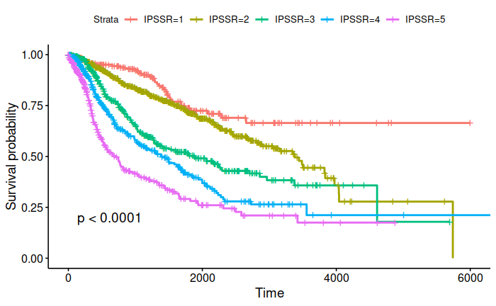

```r
km_IPSSR <- survfit(Surv(time, fup_status)~MDS_data$IPSSR, data = MDS_data)
ggsurvplot(km_IPSSR, data = MDS_data, pval = TRUE)
```

The result is consistent: higher is the IPPSR index, lower is the survival probability

We now plot the Kaplan-Meier curves between the two cohorts in every genomic group:

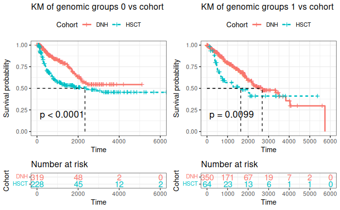

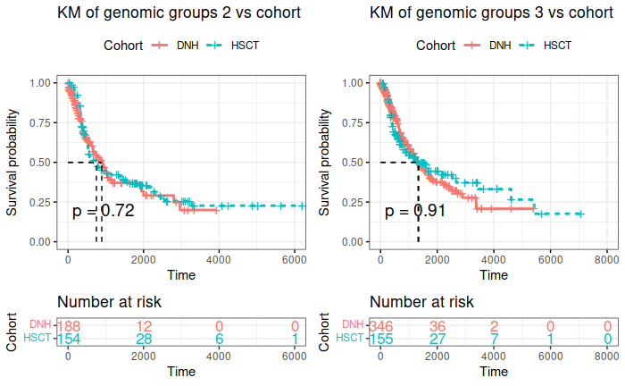

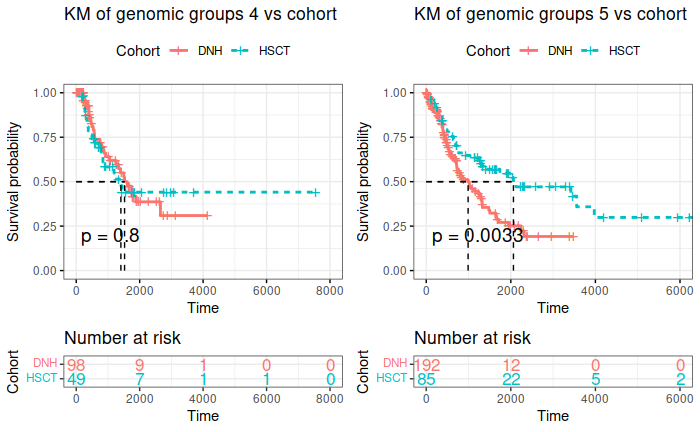

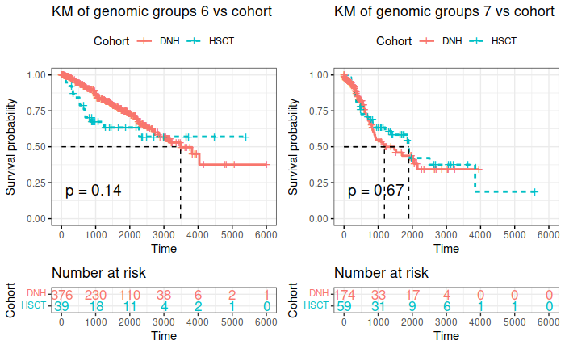

```r
plots <- list()
km_genomic_model <- list()
km_genomic_model_diff <- list()

for (i in 0:(length(levels(as.factor(MDS_data$genomic_group)))-1)) {

  km_genomic_model[[i + 1]] <- survfit(Surv(time[which(MDS_data$genomic_group == i)], MDS_data$fup_status[which(MDS_data$genomic_group == i)])
                              ~MDS_data$cohort[which(MDS_data$genomic_group == i)], data = MDS_data)

  km_genomic_model_diff[[i + 1]] <- survdiff(Surv(time[which(MDS_data$genomic_group == i)], MDS_data$fup_status[which(MDS_data$genomic_group == i)])
           ~MDS_data$cohort[which(MDS_data$genomic_group == i)], data = MDS_data)

   #print(km_genomic_model_diff[[i + 1]])

  plots[[i + 1]] = ggsurvplot(km_genomic_model[[i + 1]],
                           data = MDS_data,
                           pval = TRUE, conf.int = FALSE,
                           risk.table = TRUE, # Add risk table
                           risk.table.col = "strata", # Change risk table color by groups
                           linetype = "strata", # Change line type by groups
                           surv.median.line = "hv", # Specify median survival
                           ggtheme = theme_bw(), # Change ggplot2 theme
                           legend.title = "Cohort",
                           legend.labs = c("DNH", "HSCT"),
                           title = paste("KM of genomic groups", toString(i), "vs cohort")
                            )
}

arrange_ggsurvplots(plots)
```

These results are hard to interpret since IPSSR is not considered and, as it’s shown below, its concentration is very different between the two cohorts and, as we noticed above, it is a significant variable.

We now plot the Kaplan-Meier curves between the two cohorts for each value of IPSSR:

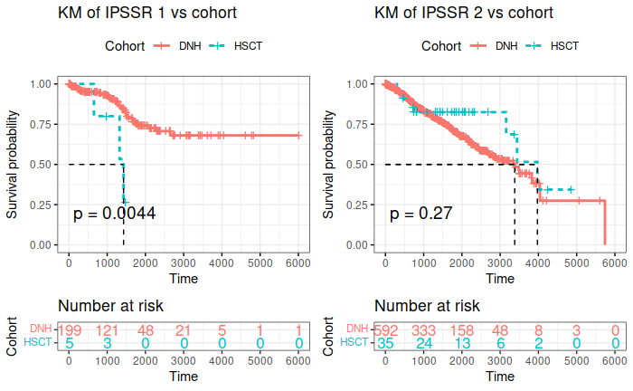

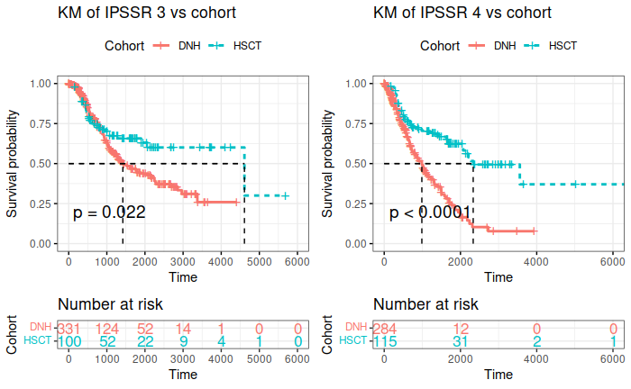

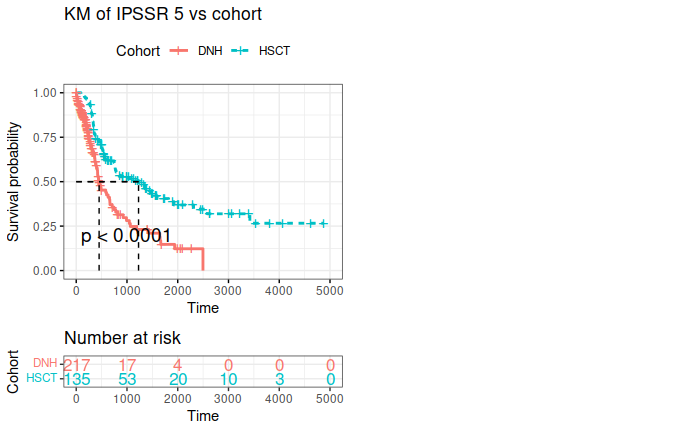

```r
plots <- list()
km.IPSSR.model <- list()
km.IPSSR.model.diff <- list()

for (i in 1:length(levels(as.factor(MDS_data$IPSSR)))) {

  km.IPSSR.model[[i]] <- survfit(Surv(time[which(MDS_data$IPSSR == i)], fup_status[which(MDS_data$IPSSR == i)])
                                    ~cohort[which(MDS_data$IPSSR == i)], data = MDS_data)

  km.IPSSR.model.diff[[i]] <- survdiff(Surv(time[which(MDS_data$IPSSR == i)], fup_status[which(MDS_data$IPSSR == i)])
                                          ~cohort[which(MDS_data$IPSSR == i)], data = MDS_data)

  plots[[i]] = ggsurvplot(km.IPSSR.model[[i]],
                              data = MDS_data,
                              pval = TRUE, conf.int = FALSE,
                              risk.table = TRUE, # Add risk table
                              risk.table.col = "strata", # Change risk table color by groups
                              linetype = "strata", # Change line type by groups
                              surv.median.line = "hv", # Specify median survival
                              ggtheme = theme_bw(), # Change ggplot2 theme
                              legend.title = "Cohort",
                              legend.labs = c("DNH", "HSCT"),
                              title = paste("KM of IPSSR", toString(i), "vs cohort")
  )
}

arrange_ggsurvplots(plots)
```

As we could expect, the transplantation has an overall positive effect for the most critical values of the IPSSR index. However we cannot say the same for the first two values: - there is no evidence to say that the curves are different for IPSSR=2 (p-value = 0.27) - for IPSSR = 1 the transplantation seems to be a bad idea However these results can also be explained by the very low number of patients which such values of IPSSR in the HSCT cohort (see below). This can cause many problems and one is the possible dominance of a specific genomic group, maybe unfavourable to the transplantation.

Here is the IPSSR distributions in the two cohorts:

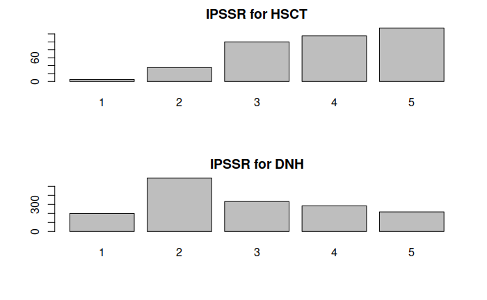

```r
layout(c(1,2))
plot(as.factor(MDS_data$IPSSR[which(MDS_data$cohort == "HSCT")]), main="IPSSR for HSCT")
plot(as.factor(MDS_data$IPSSR[which(MDS_data$cohort == "DNH")]), main="IPSSR for DNH")
```

```r
print(paste("IPSSR for HSCT mean:", mean(MDS_data$IPSSR[which(MDS_data$cohort == "HSCT")], na.rm = TRUE)))
```

```
[1] "IPSSR for HSCT mean: 3.87179487179487"
```

```r
print(paste("IPSSR for DNH mean:", mean(MDS_data$IPSSR[which(MDS_data$cohort == "DNH")], na.rm = TRUE)))
```

```
[1] "IPSSR for DNH mean: 2.83240911891559"
```

Here we reproduce the previous plots but considering genomic groups 1 and 6 as a single one, as well as groups 3 and 5. This classification is suggested in the Bersanelli’s article

```r
new_genomic_group = MDS_data$genomic_group
new_genomic_group[which(new_genomic_group==1)] = 16     #groups 1 and 6 toghether
new_genomic_group[which(new_genomic_group==6)] = 16     #groups 1 and 6 toghether
new_genomic_group[which(new_genomic_group==3)] = 35     #groups 3 and 5 toghether
new_genomic_group[which(new_genomic_group==5)] = 35     #groups 3 and 5 toghether
MDS_data <- cbind(MDS_data, new_genomic_group)
```

Kaplan-Meier curves for the new genomic groups

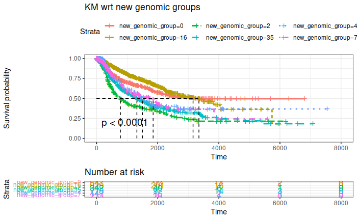

```r
km.new_genomic.model <- survfit(Surv(time, MDS_data$fup_status)~MDS_data$new_genomic_group)
ggsurvplot(km.new_genomic.model,
                         data= MDS_data,
                         pval = TRUE, conf.int = FALSE,
                         risk.table = TRUE, # Add risk table
                         risk.table.col = "strata", # Change risk table color by groups
                         linetype = "strata", # Change line type by groups
                         surv.median.line = "hv", # Specify median survival
                         ggtheme = theme_bw(), # Change ggplot2 theme
                         title = "KM wrt new genomic groups")
```

This result is actually much different from the plot in the Bersanelli’s article Kaplan-Meier curves between the two cohorts in every new genomic group:

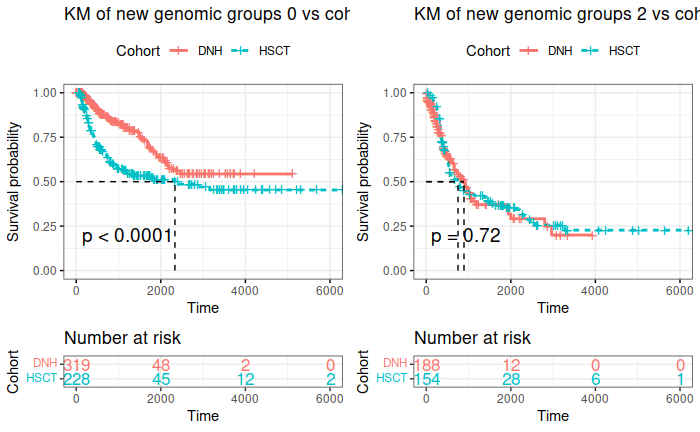

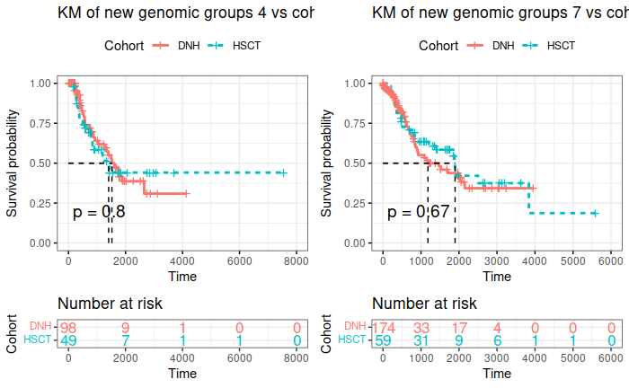

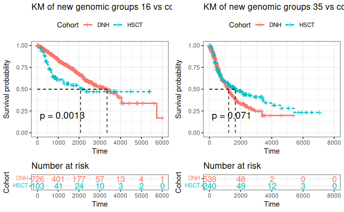

```r
plots <- list()
km_new_genomic_model <- list()
km_new_genomic_model_diff <- list()
n = 1
for (i in c(0,2,4,7,16,35)) {
  km_new_genomic_model[[n]] <- survfit(Surv(time[which(MDS_data$new_genomic_group == i)], MDS_data$fup_status[which(MDS_data$new_genomic_group == i)])
                              ~MDS_data$cohort[which(MDS_data$new_genomic_group == i)], data = MDS_data)

  km_new_genomic_model_diff[[n]] <- survdiff(Surv(time[which(MDS_data$new_genomic_group == i)], MDS_data$fup_status[which(MDS_data$new_genomic_group == i)])
           ~MDS_data$cohort[which(MDS_data$new_genomic_group == i)], data = MDS_data)

   #print(km_new_genomic_model_diff[[n]])

  plots[[n]] = ggsurvplot(km_new_genomic_model[[n]],
                           data = MDS_data,
                           pval = TRUE, conf.int = FALSE,
                           risk.table = TRUE, # Add risk table
                           risk.table.col = "strata", # Change risk table color by groups
                           linetype = "strata", # Change line type by groups
                           surv.median.line = "hv", # Specify median survival
                           ggtheme = theme_bw(), # Change ggplot2 theme
                           legend.title = "Cohort",
                           legend.labs = c("DNH", "HSCT"),
                           title = paste("KM of new genomic groups", toString(i), "vs cohort")
                            )
  n = n+1
}

arrange_ggsurvplots(plots)
```

## Assesment of PH assumpion

Now we test the PH assumption between the two cohorts plotting the -log(-log) of the survival probablity

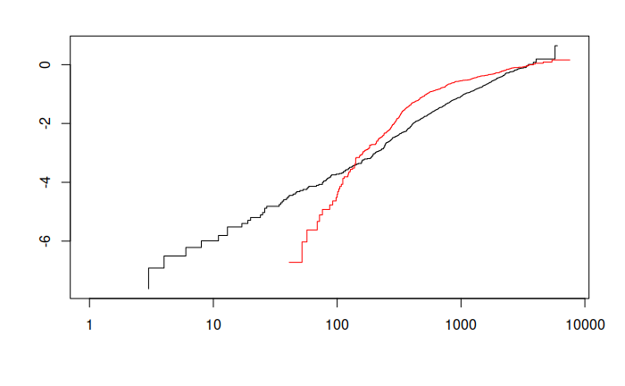

```r
# PH assumption through loglog test
fit_0 <-  survfit(Surv(time, MDS_data$fup_status)~MDS_data$cohort, data=MDS_data)

## Treatment variable (rx)
plot(fit_0,col=c("black", "red"), fun="cloglog")
```

The PH assumption is verified if the distance between the two functions is constant and this is not the case: this may suggests to treat the cohort as a time dependent variable.

## Cox PH model

We start with a simple Cox model in which the only covariate is the cohort

```r
cox.model = coxph(Surv(time, fup_status) ~ cohort, MDS_data)
summary(cox.model)
```

```
Call:
coxph(formula = Surv(time, fup_status) ~ cohort, data = MDS_data)

  n= 2876, number of events= 999

              coef exp(coef) se(coef)     z Pr(>|z|)
cohortHSCT 0.29468   1.34269  0.06468 4.556 5.21e-06 ***
---
Signif. codes:  0 ‘***’ 0.001 ‘**’ 0.01 ‘*’ 0.05 ‘.’ 0.1 ‘ ’ 1

           exp(coef) exp(-coef) lower .95 upper .95
cohortHSCT     1.343     0.7448     1.183     1.524

Concordance= 0.554  (se = 0.008 )
Likelihood ratio test= 20.31  on 1 df,   p=7e-06
Wald test            = 20.76  on 1 df,   p=5e-06
Score (logrank) test = 20.91  on 1 df,   p=5e-06
```

We try to include also genomic_group

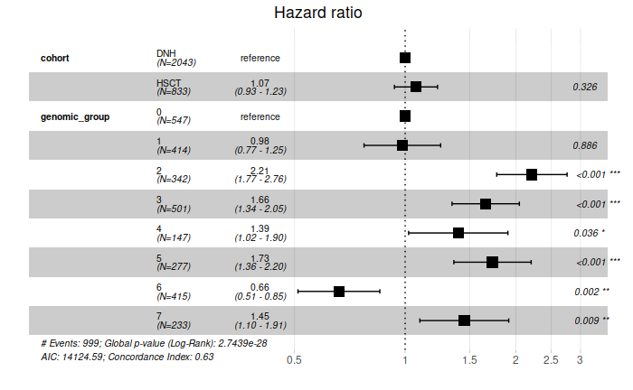

```r
cox.genomic = coxph(Surv(time, fup_status) ~ cohort + genomic_group, MDS_data)
# summary(cox.genomic)
ggforest(cox.genomic, data=MDS_data)
```

Adding genomic group makes cohort seems less important (P high, coef near to zero, exp(coef) near to 1 and .95 CI which includes 0) confirming our previous hypothesis that cohort is not enough alone to infer about the transplantation effectiveness.

It seems that few genomic groups (like 1 and 6) are associated with a good prognosis (exp(coef) < 1)) while for the others the opposite. In particular for example group 2 has exp(coef) = 2.2129 and so the risk for a patient of this group is more than 2 time the risk of a patient which is not. This is in accordance with Bersanelli who says that patients in group 2 has a mutation of TP53 which is strongly associated with a bad prognosis.

We plot the baseline

```
There are no survival curves to be compared.
 This is a null model.
```

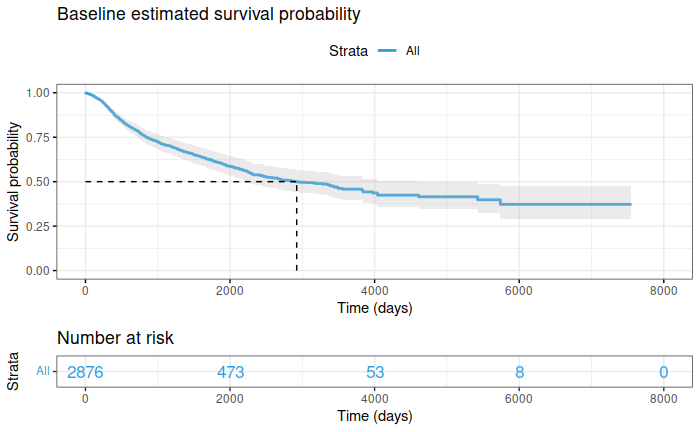

```r
ggsurvplot(survfit(cox.genomic), data=MDS_data, palette = "#2E9FDF",
           censor = F,
           pval = T, conf.int = T,
           risk.table = T,
           risk.table.col = "strata",
           linetype = "strata",
           surv.median.line = "hv",
           ggtheme = theme_bw(),
           xlab = "Time (days)",
           ylab='Survival probability',
           title = "Baseline estimated survival probability"
           )
```

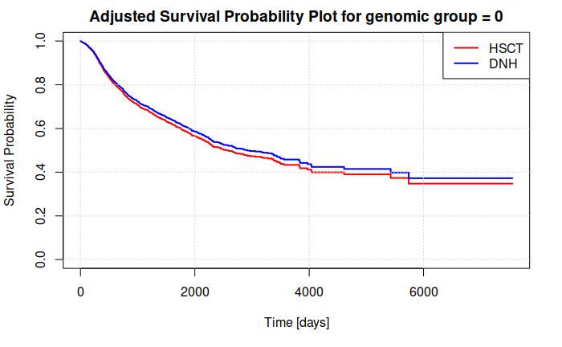

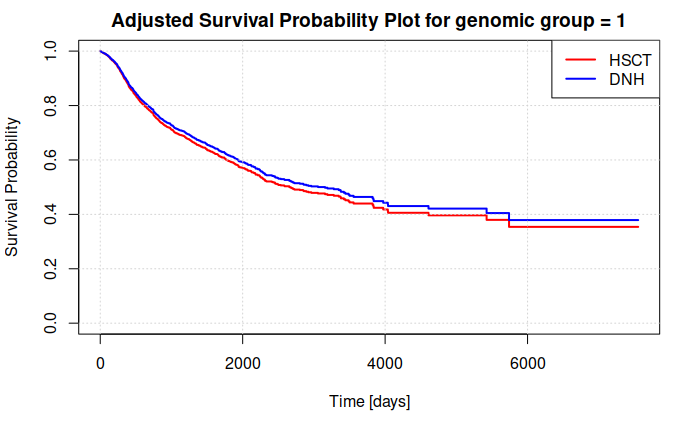

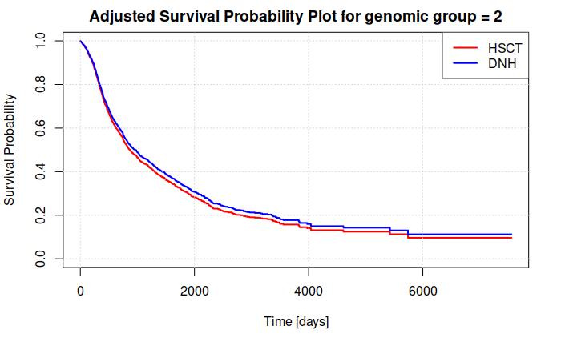

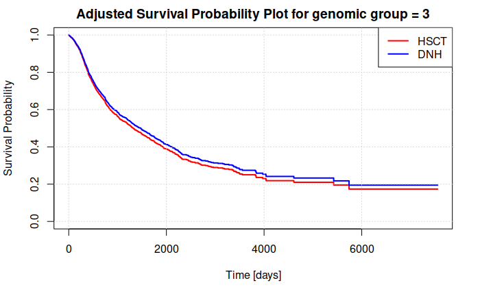

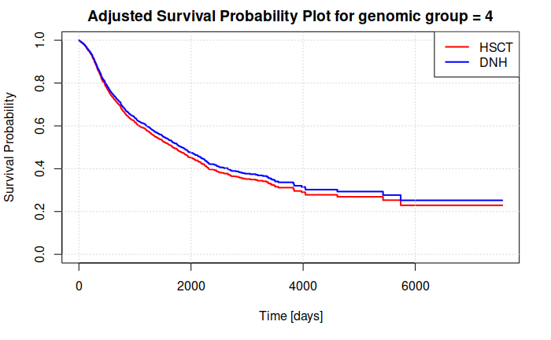

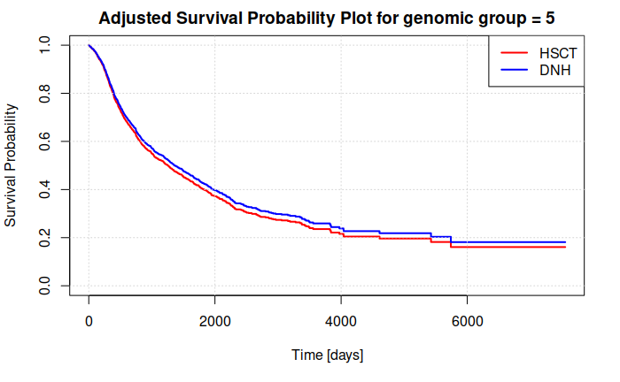

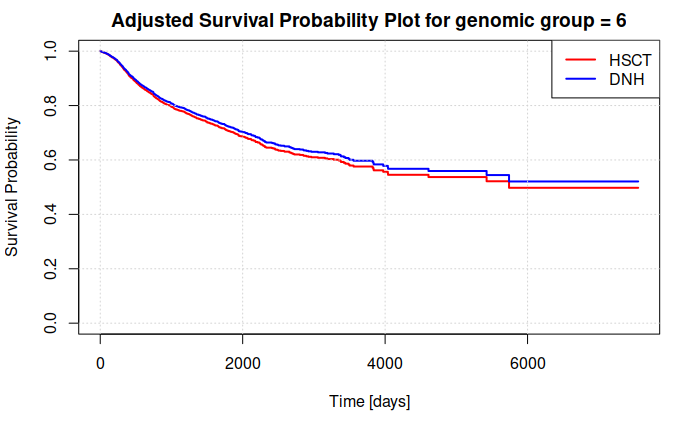

```r
for (i in 0:(length(levels(as.factor(genomic_group))) - 1)) {

  genomic_group_df <- with(MDS_data, data.frame(genomic_group = c(as.character(i)),
                                                cohort = c("HSCT", "DNH")))

  fit.genomic_group <- survfit(cox.genomic, newdata = genomic_group_df)

  plot(fit.genomic_group, conf.int=F,
       col=c("red","blue"), lwd=2, lty=1,
       xlab="Time [days]", ylab="Survival Probability",
       main = paste("Adjusted Survival Probability Plot for genomic group =", as.character((i))))
  grid()
  legend('topright', c("HSCT", "DNH"),
         lty=c(1,1,1), lwd=c(2,2,2), col=c("red","blue"))
}
```

[output not shown]